# Effect of Transmission Type on MPG

## Executive Summary

Although, it initally looked as though manual cars had a much higher MPG than automatic after regressing out car weight and the number of gears in each car that relationship filped. However, the 0.93 exponentiated regression coefficient given to manual cars in this model was not signficantly different from 1 at a 5% confidence interval, thus the results are inconclusive.

## Data Prep

The data was split for easier visualization and variables were converted to factors where appropriate. This resulted in a new data set called “cars”, which contains all variables and treats the discrete vairables as factors.

```r
library(dplyr)
library(ggplot2)
library(GGally)
cars_num<-mtcars%>%select(mpg, am, disp, hp, drat,wt,qsec)
cars_fac<-mtcars%>%select(mpg, am, cyl,vs,gear,carb)
cars_fac$am<-factor(cars_fac$am, labels=c("Auto","Manual"))
cars_fac$cyl<-factor(cars_fac$cyl)
cars_fac$vs<-factor(cars_fac$vs, labels=c("v","s"))
cars_fac$gear<-factor(cars_fac$gear)
cars_fac$carb<-factor(cars_fac$carb)
cars<-cbind(cars_fac,cars_num[,3:7])
```

## Exploratory Analysis

### Numeric variables

Figure 1 in the appendix shows that all numeric varibles have reasonably strong correlations with MPG. However, as seen in table 1 of the appendix, only 3 of these five have significantly different means when they are compared across transmission type. Of those 3 weight (wt) and engine displacment (disp) are very strongly correlated to each other (0.888) it makes sense that the size of the engine would have this sort of relationship with weight so both variables do not need to be included. Engine displacement has been dropped in favor of car weight because the car weight is slighly more correlated with mpg. This leaves us with 2 numeric variables weight of the car (wt) and rear axel ratio (drat).

### Discrete Variables

Looking at figure 2 in the appendix it is clear that the automatic cars are much more likely than manual to have only 3 gears (gear). Cars with three gears seem to have significantly worse MPG so this might be a possible confounding variable. The same figure also shows that automatic cars tend to have more cylinders than manual and that the number of cylinders a car has is inversly correlated with MPG. However, the number of cylinders is also closely tied to the number of gears with almost all cars that have 8 cylinders having 3 gears, thus only one of these should probably be included. Cars with their cylinders shaped in a V instead of a straight line also seems to get worse gas milage and those cars are also more likely to have automatic transmissions, but this again seems to be correlated to both the gear and cylinder number. Finally, the number of carborators in a car seems to be inversly related to the MPG but that relationship isn’t as strong as the others. Thus, carborator amount will not be examined. Cylinder number and configuration as well as the amount of gears in a car will all be examined but their heavy correlation to one another indicts that all will most likely not be present in the final model.

## Model Selection

```r
fit<-glm(mpg~am+wt+gear,family="quasipoisson",data=cars)
```

## Residuals

Figure 3 in the appendix shows that the reidudals are relatively constant throughout different predicted values which is alright because we are using the Quasipoisson transformation instead of a standard Poisson.

## Conclusion

The most appropriate model appears to use only transmission type, the weight of the car, and the number of gears as the predictor variables. This model yields a coefficient of 0.93 suggesting that manual cars are 7% less fuel efficient than automatic once weight and the number of gears are held constant.

```r
exp(coef(fit))
```

```
## (Intercept)    amManual          wt       gear4       gear5
##  46.8117686   0.9284591   0.7555806   1.1346574   1.0070405
```

However, the confidence interval of this coefficient contains 1 meaning the null hypothesis cannot be rejected and nothing can be said about the affects of transmission type on mpg.

```r
exp(confint(fit))
```

```
##                  2.5 %     97.5 %
## (Intercept) 35.2418038 62.1455817
## amManual     0.7881122  1.0958902
## wt           0.7017106  0.8130431
## gear4        0.9799125  1.3099472
## gear5        0.8277912  1.2219129
```

## Apendix

### Table 1

```r
out <- data.frame("var1" = character()
, "var2"=character()
,"auto.mean"=integer()
,"manual.mean"=integer()
, "t.value"=integer()
, "df"=integer()
, "p.value"=double()
,row.names=NULL
)
for(i in 3:length(colnames(cars_num)))
{
test<-t.test(cars_num[,i]~am, data=cars_num)

out2 <- data.frame("var1" = colnames(cars_num)[i]
, "var2" = "am"
,"auto.mean"=test$estimate[1]
,"manual.mean"=test$estimate[2]
, "t.value" = sprintf("%.3f", test$statistic)
, "df"= test$parameter
, "p.value" = sprintf("%.3f", test$p.value)
,row.names=NULL
)
out<-rbind(out, out2)
}
out
```

```
##   var1 var2  auto.mean manual.mean t.value       df p.value
## 1 disp   am 290.378947    143.5308   4.198 29.25845   0.000
## 2   hp   am 160.263158    126.8462   1.266 18.71541   0.221
## 3 drat   am   3.286316      4.0500  -5.646 27.19780   0.000
## 4   wt   am   3.768895      2.4110   5.494 29.23352   0.000
## 5 qsec   am  18.183158     17.3600   1.288 25.53421   0.209
```

### Table 2

```r
fit1<-glm(mpg~am,family="quasipoisson",data=cars)
fit2<-glm(mpg~am+wt,family="quasipoisson",data=cars)
fit3<-glm(mpg~am+wt+gear,family="quasipoisson",data=cars)
fit4<-glm(mpg~am+wt+gear+vs,family="quasipoisson",data=cars)
fit5<-glm(mpg~am+wt+gear+vs+cyl,family="quasipoisson",data=cars)
fit6<-glm(mpg~am+wt+gear+vs+cyl+drat,family="quasipoisson",data=cars)
anova(fit1,fit2,fit3,fit4,fit5,fit6, test="Chisq")
```

```
## Analysis of Deviance Table
##
## Model 1: mpg ~ am
## Model 2: mpg ~ am + wt
## Model 3: mpg ~ am + wt + gear
## Model 4: mpg ~ am + wt + gear + vs
## Model 5: mpg ~ am + wt + gear + vs + cyl
## Model 6: mpg ~ am + wt + gear + vs + cyl + drat
##   Resid. Df Resid. Dev Df Deviance Pr(>Chi)
## 1        30     34.699
## 2        29     10.449  1  24.2498  < 2e-16 ***
## 3        27      8.571  2   1.8785  0.04755 *
## 4        26      7.949  1   0.6218  0.15560
## 5        24      7.064  2   0.8852  0.23806
## 6        23      6.969  1   0.0946  0.57962
## ---
## Signif. codes:  0 '***' 0.001 '**' 0.01 '*' 0.05 '.' 0.1 ' ' 1
```

### Table 3

```r
fit1<-glm(mpg~am,family="quasipoisson",data=cars)
fit2<-glm(mpg~am+wt,family="quasipoisson",data=cars)
fit3<-glm(mpg~am+wt+cyl,family="quasipoisson",data=cars)
fit4<-glm(mpg~am+wt+cyl+gear,family="quasipoisson",data=cars)
anova(fit1,fit2,fit3,fit4, test="Chisq")
```

```
## Analysis of Deviance Table
##
## Model 1: mpg ~ am
## Model 2: mpg ~ am + wt
## Model 3: mpg ~ am + wt + cyl
## Model 4: mpg ~ am + wt + cyl + gear
##   Resid. Df Resid. Dev Df Deviance  Pr(>Chi)
## 1        30     34.699
## 2        29     10.449  1  24.2498 < 2.2e-16 ***
## 3        27      7.474  2   2.9752  0.005689 **
## 4        25      7.073  2   0.4005  0.498682
## ---
## Signif. codes:  0 '***' 0.001 '**' 0.01 '*' 0.05 '.' 0.1 ' ' 1
```

### Table 4

```r
fit1<-glm(mpg~am,family="quasipoisson",data=cars)
fit2<-glm(mpg~am+wt,family="quasipoisson",data=cars)
fit3<-glm(mpg~am+wt+vs,family="quasipoisson",data=cars)
fit4<-glm(mpg~am+wt+vs+gear,family="quasipoisson",data=cars)
anova(fit1,fit2,fit3,fit4, test="Chisq")
```

```
## Analysis of Deviance Table
##
## Model 1: mpg ~ am
## Model 2: mpg ~ am + wt
## Model 3: mpg ~ am + wt + vs
## Model 4: mpg ~ am + wt + vs + gear
##   Resid. Df Resid. Dev Df Deviance Pr(>Chi)
## 1        30     34.699
## 2        29     10.449  1  24.2498  < 2e-16 ***
## 3        28      8.431  1   2.0176  0.01114 *
## 4        26      7.949  2   0.4827  0.46262
## ---
## Signif. codes:  0 '***' 0.001 '**' 0.01 '*' 0.05 '.' 0.1 ' ' 1
```

### Table 5

```r
fit1<-glm(mpg~am,family="quasipoisson",data=cars)
fit2<-glm(mpg~am+wt,family="quasipoisson",data=cars)
fit3<-glm(mpg~am+wt+drat,family="quasipoisson",data=cars)
fit4<-glm(mpg~am+wt+drat+gear,family="quasipoisson",data=cars)
anova(fit1,fit2,fit3,fit4, test="Chisq")
```

```
## Analysis of Deviance Table
##
## Model 1: mpg ~ am
## Model 2: mpg ~ am + wt
## Model 3: mpg ~ am + wt + drat
## Model 4: mpg ~ am + wt + drat + gear
##   Resid. Df Resid. Dev Df Deviance Pr(>Chi)
## 1        30     34.699
## 2        29     10.449  1  24.2498  < 2e-16 ***
## 3        28     10.136  1   0.3132  0.33586
## 4        26      8.543  2   1.5925  0.09493 .
## ---
## Signif. codes:  0 '***' 0.001 '**' 0.01 '*' 0.05 '.' 0.1 ' ' 1
```

### Figure 1

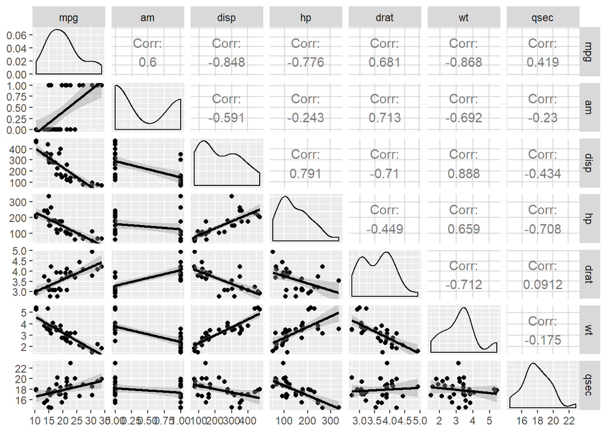

```r
g=ggpairs(cars_num, lower = list(continuous="smooth",discrete="facetbar"), diag=list(continuous="densityDiag"))
g
```

### Figrue 2

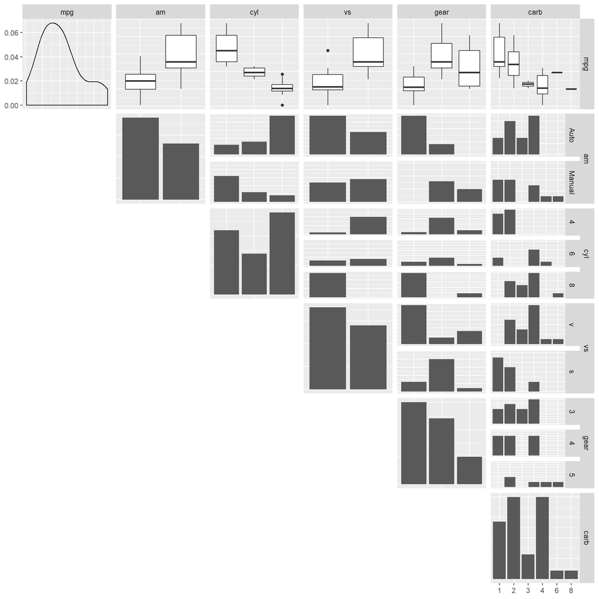

```r
g2=ggpairs(cars_fac, lower = list(combo="blank",discrete="blank"), diag=list(continuous="densityDiag"))
g2
```

### Figrue 3

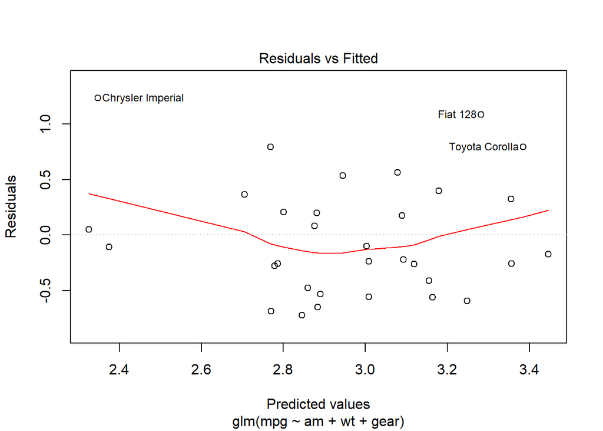

```r
plot(fit, which=1)
```